# Economic Modeling

Are Trade Deficits Bad?

Andrej Arpáš

12/16/2019

# Introduction

This project aims at applying sound quantitative methods and data analytics in the realm of computational and mathematical statistics to economic output and the trade deficit and the extent to which it can or cannot be said that the latter is “bad” for the former.

Running a trade deficit is what happens when a country imports more than it exports. The converse of that is referred to as a surplus. Both phenomena are forms of a lopsided trade balance, somewhat broader measure of which is the current account. Standard economic theory is unambiguous that the trade deficit is something not to be worried about. This, however, does not appear to be how the trade deficit tends to be perceived by the general public or written about in many a media outlet. The objective of this paper, therefore, is to analyze those metrics that, in one form or another, pertain to the trade deficit, such as I(M)ports, E(X)ports, the Trade Deficit (X-M), GDP data to gauge economic output, and the unemployment rate for the past ten years, from 2008 to 2018. (The data is quarterly and therefore 2019 could not be taken into account seeing that the last quarter had not been reported yet.)

## Research Question: “Are Trade Deficits Bad?”

The research question harkens back to the “infamous” economic identity $Y = G + I + C + NX$, where $Y$ denotes output, $G$ government spending, $I$ private investment, $C$ consumer spending, and $NX$ stands for net exports or the difference between exports and imports. It is this last term of the identity that seems to make some believe that since one takes away imports in order to arrive at the $Y$ figure, imports must be bad for the economy. This, however, is merely a book-keeping operation intended to ensure that the final figure not be overestimated. The subtracting is necessary lest imports are double-counted in all the other terms. (Imports are part of certain exports, the consumer spending, investments by companies and domestic manufacturers, and even government procurement allows for foreign-sourced components and so on.) Posing the question in such simplistic terms allows one to arrive at a falsifiable hypothesis and makes modelling more interesting.

## Hypothesis & Methods

I shall begin by presuming the trade deficit is indeed bad for the economy. What does “bad” mean in this context? “Bad” will be defined by the data to hold up the following relationship: The greater the trade deficit, the lower the output and vice versa.

(As a corollary, I will also be tracking unemployment rates over the same time span since unemployment seems to be frequently lumped together with lower economic output, i.e. as yet another victim of the oft-vilified trade deficit. However, since the two are indeed paired up in economic literature, unemployment is largely redundant as a measurement tool in order to study the relationship between the trade deficit and economic output since the output and unemployment could be considered almost complements of sorts in the sense that there might be overlaps in terms of what one may learn about the trade deficit by observing either of the two.)

For the purposes of this paper, output is the dependent variable, and it depends on independent variables in my models, such as the trade deficit, unemployment rates and so forth.

The metrics of interest will be estimates of the extent to which GDP/output is predicated on the trade deficit. Statistically significant findings ($\alpha < 0.05$) of a positive association between the trade deficit and the GDP will be taken as indicative of the rejection of the null, and therefore a proof by contradiction that the trade deficit is actually “good” for the economy, i.e. conducive to economic growth.

Caveat worth keeping in mind throughout: both GDP and the trade-deficit magnitude trend over 2008–2018. Associational models on levels can therefore pick up shared time trends rather than a structural causal effect. The exercise remains useful as a descriptive / falsification-style check against the folk claim that deficits mechanically depress output.

In the Random Forests (RF) phase of my experiment, the output will be my estimand, estimated by my RF model (the estimator), and the predictions yielded by this model will be my estimates.

# Data Description

The data comes from three primary sources. All data in this project describes the United States economy and comes from U.S. sources only.

## GDP

Obtained from the Bureau of Economic Analysis (BEA), the data pertains to the Real Gross Domestic Product, in chained (2012) dollars, seasonally adjusted at annual rates, raw and converted in billions. (2008-2018, quarterly.)

## Imports/Exports

Source of this data is the United States International Trade Commission (USITC), Imports for Consumption, i.e. imports physically cleared through Customs (in Customs value), and Domestic Exports (FAS value - i.e. a measure of the total value), i.e. of U.S. or foreign origin if the latter have been significantly enhanced in value in the U.S. so as to be considered “domestic”. The data comes raw, parsed at the 2-digit level (HTS-2) and is downloaded as aggregate and subsequently converted to get billions. The USITC web interface displays the data as monthly and quarterly values are obtained by adding up the months.

## Unemployment Rate

This data is reported monthly, in percent terms. Quarterly data is calculated using a mean of the monthly values. It is publicly accessible from the Bureau of Labor Statistics (BLS) website.

# Data Analysis/Modelling

Let’s begin by loading the data…

```r
raw <- readr::read_csv(file.path(data_dir, "agg_d.csv"), show_col_types = FALSE)

# Wide file: first column is metric name; remaining columns are quarters.
metric <- raw[[1]]
mat <- as.matrix(raw[, -1])
rownames(mat) <- metric
e <- as.data.frame(t(mat), stringsAsFactors = FALSE)
e <- e |>
  mutate(across(everything(), as.numeric)) |>
  rownames_to_column("Quarters")

# Boolean trade deficit and magnitude.
e <- e |>
  mutate(
    TradeDeficit = as.integer(Exports_Q - Imports_Q < 0),
    TradeDeficit_Size = abs(Exports_Q - Imports_Q),
    GDP_Bn = Gdp_bn,
    UnemploymentRate_Q = Ur_Q,
    TradeDeficit_Size_Bn = TradeDeficit_Size / 1e9,
    Imports_Bn = Imports_Q / 1e9,
    UnemploymentRate_Numeric = UnemploymentRate_Q / 100
  )

str(e)
```

```
'data.frame':   44 obs. of  12 variables:
 $ Quarters                : chr  "2008Q1" "2008Q2" "2008Q3" "2008Q4" ...
 $ Gdp_bn                  : num  15671 15752 15667 15328 15156 ...
 $ Imports_Q               : num  4.99e+11 5.47e+11 5.69e+11 4.76e+11 3.53e+11 ...
 $ Exports_Q               : num  2.86e+11 3.10e+11 3.07e+11 2.67e+11 2.20e+11 ...
 $ Ur_Q                    : num  5 5.3 6 6.9 8.3 9.3 9.6 9.9 9.8 9.6 ...
 $ TradeDeficit            : int  1 1 1 1 1 1 1 1 1 1 ...
 $ TradeDeficit_Size       : num  2.13e+11 2.37e+11 2.61e+11 2.09e+11 1.33e+11 ...
 $ GDP_Bn                  : num  15671 15752 15667 15328 15156 ...
 $ UnemploymentRate_Q      : num  5 5.3 6 6.9 8.3 9.3 9.6 9.9 9.8 9.6 ...
 $ TradeDeficit_Size_Bn    : num  213 237 261 209 133 ...
 $ Imports_Bn              : num  499 547 569 476 353 ...
 $ UnemploymentRate_Numeric: num  0.05 0.053 0.06 0.069 0.083 0.093 0.096 0.099 0.098 0.096 ...
```

Okay, now we’re ready to do some computation. We’re almost done pre-processing. We’ve got columns: GDP ($ Billions), Imports, Exports, Unemployment Rate. All quarterly for ten years from 2008 to 2018.

Now, I may want to do a Boolean on whether there is a trade deficit (1) or not (0). Plus, let’s make another column and call it the TBalance to stand for the Balance-of-Trade, positive would mean Trade Surplus, and negative values would denote the sought after Trade Deficit.

Running this operator and checking the df (data frame), one sees that the U.S. has had a continuous trade deficit for the entire observed period. Having thus confirmed what one might already have suspected, that is, that the U.S. has run a trade deficit the whole time, it makes more sense to create another vector which won’t be the Balance-of-Trade, but instead we shall hone in on the Trade Deficit. Specifically, its quantity/magnitude, i.e. I will be looking at the absolute value of the Trade Deficit. We shall call this column `TradeDeficit_Size`. (Let’s remind ourselves that the units are what they were for Exports/Imports, i.e. just $US.)

Okay, we’re ready to do a summary:

```r
summary(e$TradeDeficit_Size)
```

```
     Min.   1st Qu.    Median      Mean   3rd Qu.      Max.
1.330e+11 2.111e+11 2.310e+11 2.259e+11 2.446e+11 3.052e+11
```

```r
summary(e |> select(GDP_Bn, Imports_Q, Exports_Q, UnemploymentRate_Q, TradeDeficit_Size_Bn))
```

```
     GDP_Bn        Imports_Q           Exports_Q         UnemploymentRate_Q
 Min.   :15134   Min.   :3.527e+11   Min.   :2.197e+11   Min.   :3.800
 1st Qu.:15741   1st Qu.:5.078e+11   1st Qu.:3.060e+11   1st Qu.:4.900
 Median :16467   Median :5.598e+11   Median :3.240e+11   Median :6.450
 Mean   :16700   Mean   :5.415e+11   Mean   :3.156e+11   Mean   :6.686
 3rd Qu.:17577   3rd Qu.:5.728e+11   3rd Qu.:3.409e+11   3rd Qu.:8.375
 Max.   :18784   Max.   :6.615e+11   Max.   :3.643e+11   Max.   :9.900
 TradeDeficit_Size_Bn
 Min.   :133.0
 1st Qu.:211.1
 Median :231.0
 Mean   :225.9
 3rd Qu.:244.6
 Max.   :305.2
```

```r
as_tibble(e)
```

```
# A tibble: 44 × 12
   Quarters Gdp_bn    Imports_Q   Exports_Q  Ur_Q TradeDeficit TradeDeficit_Size
   <chr>     <dbl>        <dbl>       <dbl> <dbl>        <int>             <dbl>
 1 2008Q1   15671. 499293138893     2.86e11   5              1      213193004550
 2 2008Q2   15752. 546764933914     3.10e11   5.3            1      236746934192
 3 2008Q3   15667  568544457479     3.07e11   6              1      261463305767
 4 2008Q4   15328  475880224242     2.67e11   6.9            1      209258191285
 5 2009Q1   15156. 352671071726     2.20e11   8.3            1      132982227909
 6 2009Q2   15134. 359662090967     2.23e11   9.3            1      136332606356
 7 2009Q3   15189. 403440413977     2.34e11   9.6            1      169296154960
 8 2009Q4   15356. 433389908612     2.60e11   9.9            1      173807537666
 9 2010Q1   15415. 422974305699     2.62e11   9.8            1      161378259707
10 2010Q2   15557. 476011585435     2.77e11   9.6            1      199274284222
# ℹ 34 more rows
# ℹ 5 more variables: GDP_Bn <dbl>, UnemploymentRate_Q <dbl>,
#   TradeDeficit_Size_Bn <dbl>, Imports_Bn <dbl>,
#   UnemploymentRate_Numeric <dbl>
```

To just work with USD billions… (Might be easier to work with. It also lines up better with the GDP data, which is in billions.)

Let’s visualize what we’re dealing with:

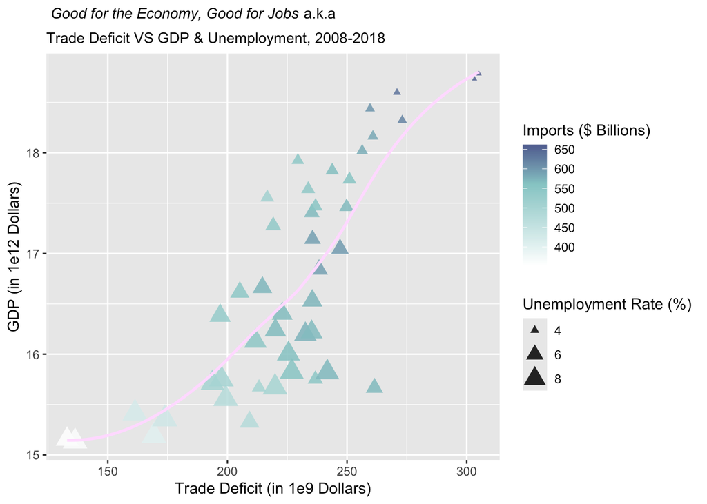

```r
mid <- median(e$Imports_Bn)

first_glance <- ggplot(e) +
  geom_point(
    aes(
      x = TradeDeficit_Size_Bn,
      y = GDP_Bn / 1000,
      color = Imports_Bn,
      size = UnemploymentRate_Q
    ),
    shape = 17,
    alpha = 0.85
  ) +
  scale_color_gradient2(
    midpoint = mid,
    low = "white",
    mid = "paleturquoise3",
    high = "midnightblue",
    space = "Lab"
  ) +
  geom_smooth(
    aes(x = TradeDeficit_Size_Bn, y = GDP_Bn / 1000),
    colour = "thistle1",
    se = FALSE,
    method = "loess",
    formula = y ~ x
  ) +
  labs(
    title = expression(" "*italic("Good for the Economy, Good for Jobs")*" a.k.a"),
    subtitle = "Trade Deficit VS GDP & Unemployment, 2008-2018",
    x = "Trade Deficit (in 1e9 Dollars)",
    y = "GDP (in 1e12 Dollars)",
    size = "Unemployment Rate (%)",
    colour = "Imports ($ Billions)"
  ) +
  theme(
    plot.title = element_text(size = 10.5),
    plot.subtitle = element_text(size = 10.5)
  )

first_glance
```

This is informative. We do see, and begin to suspect, that the trade deficit may not be such a bad thing after all. Looking at this chart, I’m expecting those stat. signif. findings to start pouring in. Let’s do a few models. Start with the simplest…

## Phase #1: Simple OLS

```r
lm1 <- lm(GDP_Bn ~ TradeDeficit_Size_Bn, data = e)
summary(lm1)
```

```
Call:
lm(formula = GDP_Bn ~ TradeDeficit_Size_Bn, data = e)

Residuals:
    Min      1Q  Median      3Q     Max
-1883.5  -424.1   184.4   524.9  1140.9

Coefficients:
                      Estimate Std. Error t value Pr(>|t|)
(Intercept)          11295.168    677.350  16.676  < 2e-16 ***
TradeDeficit_Size_Bn    23.924      2.962   8.077 4.37e-10 ***
---
Signif. codes:  0 '***' 0.001 '**' 0.01 '*' 0.05 '.' 0.1 ' ' 1

Residual standard error: 699 on 42 degrees of freedom
Multiple R-squared:  0.6084,    Adjusted R-squared:  0.599
F-statistic: 65.24 on 1 and 42 DF,  p-value: 4.366e-10
```

Simple linear model tells me that, indeed, as expected, every additional billion dollars’ increase in the trade deficit, leads to a large, statistically significant increase in the GDP. Indeed, we get a very small p-value. (Adjusted R-squared is substantial.) Again: shared trends can inflate this association.

Now, let’s do something a little more clever…

```r
lm2 <- lm(GDP_Bn ~ (TradeDeficit_Size_Bn + Imports_Bn + UnemploymentRate_Q)^2, data = e)
summary(lm2)
```

```
Call:
lm(formula = GDP_Bn ~ (TradeDeficit_Size_Bn + Imports_Bn + UnemploymentRate_Q)^2,
    data = e)

Residuals:
     Min       1Q   Median       3Q      Max
-1301.06  -110.94    27.81   216.90   745.88

Coefficients:
                                          Estimate Std. Error t value Pr(>|t|)
(Intercept)                             -1.511e+03  6.955e+03  -0.217   0.8292
TradeDeficit_Size_Bn                     3.289e+01  3.787e+01   0.868   0.3908
Imports_Bn                               3.626e+01  1.726e+01   2.101   0.0425
UnemploymentRate_Q                       1.234e+03  4.998e+02   2.469   0.0183
TradeDeficit_Size_Bn:Imports_Bn         -5.230e-02  3.571e-02  -1.465   0.1515
TradeDeficit_Size_Bn:UnemploymentRate_Q -2.279e+00  4.056e+00  -0.562   0.5776
Imports_Bn:UnemploymentRate_Q           -2.056e+00  2.076e+00  -0.990   0.3285

(Intercept)
TradeDeficit_Size_Bn
Imports_Bn                              *
UnemploymentRate_Q                      *
TradeDeficit_Size_Bn:Imports_Bn
TradeDeficit_Size_Bn:UnemploymentRate_Q
Imports_Bn:UnemploymentRate_Q
---
Signif. codes:  0 '***' 0.001 '**' 0.01 '*' 0.05 '.' 0.1 ' ' 1

Residual standard error: 425.4 on 37 degrees of freedom
Multiple R-squared:  0.8722,    Adjusted R-squared:  0.8515
F-statistic:  42.1 on 6 and 37 DF,  p-value: 4.547e-15
```

While this is nice, pair-wise interactions are a good thing just to get the sense of how the data behaves when jostled together, however, doing interactions among everything strains credulity. Try again…

Let’s try an interaction with the unemployment rate, while conditioning the unemployment to hover at about the full-employment level (threshold $\pm 1\%$), which in the U.S. is generally thought to be 5%…

```r
# Replaces the former QMSS::near() helper.
near_full_employment <- abs(e$UnemploymentRate_Numeric - 0.05) <= 1e-2
lm4 <- lm(
  GDP_Bn ~ TradeDeficit_Size_Bn:near_full_employment,
  data = e
)
summary(lm4)
```

```
Call:
lm(formula = GDP_Bn ~ TradeDeficit_Size_Bn:near_full_employment,
    data = e)

Residuals:
    Min      1Q  Median      3Q     Max
-2164.9  -208.7   106.0   437.4  1166.8

Coefficients:
                                                Estimate Std. Error t value
(Intercept)                                    11736.641    661.481  17.743
TradeDeficit_Size_Bn:near_full_employmentFALSE    21.023      3.017   6.967
TradeDeficit_Size_Bn:near_full_employmentTRUE     23.312      2.800   8.326
                                               Pr(>|t|)
(Intercept)                                     < 2e-16 ***
TradeDeficit_Size_Bn:near_full_employmentFALSE 1.83e-08 ***
TradeDeficit_Size_Bn:near_full_employmentTRUE  2.37e-10 ***
---
Signif. codes:  0 '***' 0.001 '**' 0.01 '*' 0.05 '.' 0.1 ' ' 1

Residual standard error: 658.3 on 41 degrees of freedom
Multiple R-squared:  0.6609,    Adjusted R-squared:  0.6444
F-statistic: 39.96 on 2 and 41 DF,  p-value: 2.348e-10
```

When the unemployment rate is within one percent of the full-employment level (i.e. 5%), for each additional billion dollar increase in the trade deficit, the GDP association remains positive and statistically significant. There does not appear to be much difference within vs. without the bounds, though.

```r
lm7 <- lm(GDP_Bn ~ TradeDeficit_Size_Bn + UnemploymentRate_Q, data = e)
summary(lm7)
```

```
Call:
lm(formula = GDP_Bn ~ TradeDeficit_Size_Bn + UnemploymentRate_Q,
    data = e)

Residuals:
     Min       1Q   Median       3Q      Max
-1607.51   -28.85   132.06   281.70   509.40

Coefficients:
                      Estimate Std. Error t value Pr(>|t|)
(Intercept)          16953.009   1042.209  16.266  < 2e-16 ***
TradeDeficit_Size_Bn     9.341      3.203   2.916  0.00572 **
UnemploymentRate_Q    -353.487     57.340  -6.165 2.52e-07 ***
---
Signif. codes:  0 '***' 0.001 '**' 0.01 '*' 0.05 '.' 0.1 ' ' 1

Residual standard error: 509.7 on 41 degrees of freedom
Multiple R-squared:  0.7968,    Adjusted R-squared:  0.7868
F-statistic: 80.36 on 2 and 41 DF,  p-value: 6.521e-15
```

Adjusted R-squared improves relative to `lm1`. With every one percent increase in the unemployment rate, net all else, the predicted GDP goes down substantially. Compared to `lm1`, this model’s Adj. $R^2$ goes up while the Trade Deficit coefficient shrinks, though both remain statistically significant. What I should say here is that although accounting for the Unemployment Rate did help explain away more of my data, these results should be viewed through the prism of the so-called difference version of Okun’s Law, which is a proven concept in standard economic theory that describes how quarterly changes in the unemployment rate move hand-in-hand with the growth in real output. (The GDP data I have is real output.) So, we already know there is this relationship, which allows us to surmise that though we have the Trade Deficit capture the $M$ part of the output identity $Y = G + I + C + (X-M)$, the unemployment may be capturing fragments of the other elements so adding it into the model is like mirroring the GDP, a little bit like using the GDP to predict the GDP, just obtusely. Plus, we may overestimate the trade portion of the identity since both the Trade Deficit and the Unemployment Rate may be drawing on similar factors for their predictiveness. For my other models, I think it best to steer clear of the Unemployment Rate.

```r
stargazer(lm1, lm7, type = "text")
```

```
==================================================================
                                  Dependent variable:
                     ---------------------------------------------
                                        GDP_Bn
                              (1)                    (2)
------------------------------------------------------------------
TradeDeficit_Size_Bn       23.924***               9.341***
                            (2.962)                (3.203)

UnemploymentRate_Q                               -353.487***
                                                   (57.340)

Constant                 11,295.170***          16,953.010***
                           (677.350)             (1,042.209)

------------------------------------------------------------------
Observations                   44                     44
R2                           0.608                  0.797
Adjusted R2                  0.599                  0.787
Residual Std. Error    699.006 (df = 42)      509.658 (df = 41)
F Statistic          65.242*** (df = 1; 42) 80.364*** (df = 2; 41)
==================================================================
Note:                                  *p<0.1; **p<0.05; ***p<0.01
```

```r
anova(lm1, lm7)
```

```
Analysis of Variance Table

Model 1: GDP_Bn ~ TradeDeficit_Size_Bn
Model 2: GDP_Bn ~ TradeDeficit_Size_Bn + UnemploymentRate_Q
  Res.Df      RSS Df Sum of Sq      F    Pr(>F)
1     42 20521577
2     41 10649793  1   9871784 38.005 2.522e-07 ***
---
Signif. codes:  0 '***' 0.001 '**' 0.01 '*' 0.05 '.' 0.1 ' ' 1
```

Although running a partial F-test shows that the new variable improved the model fit, I still think it’s a bad idea to include it.

## Phase #2: Ordinal Logit Regression. Try that…

In order to do so, I’ll have to convert the GDP such that categories are ordered.

```r
quintiles <- quantile(e$GDP_Bn, probs = seq(0, 1, 1 / 5), na.rm = TRUE)

g <- e |>
  mutate(
    GDP_ByQuintiles = cut(
      GDP_Bn,
      breaks = quintiles,
      include.lowest = TRUE,
      labels = c("Lowest", "Low", "Moderate", "Higher", "High")
    )
  )

ordinal.logit1 <- vglm(
  GDP_ByQuintiles ~ TradeDeficit_Size_Bn,
  data = g,
  family = propodds
)
summary(ordinal.logit1)
```

```
Call:
vglm(formula = GDP_ByQuintiles ~ TradeDeficit_Size_Bn, family = propodds,
    data = g)

Coefficients:
                      Estimate Std. Error z value Pr(>|z|)
(Intercept):1        -15.56859    3.62264  -4.298 1.73e-05 ***
(Intercept):2        -17.34448    3.79876  -4.566 4.98e-06 ***
(Intercept):3        -18.58788    3.92152  -4.740 2.14e-06 ***
(Intercept):4        -20.42335    4.11191  -4.967 6.80e-07 ***
TradeDeficit_Size_Bn   0.07958    0.01686   4.720 2.36e-06 ***
---
Signif. codes:  0 '***' 0.001 '**' 0.01 '*' 0.05 '.' 0.1 ' ' 1

Names of linear predictors: logitlink(P[Y>=2]), logitlink(P[Y>=3]),
logitlink(P[Y>=4]), logitlink(P[Y>=5])

Residual deviance: 99.7717 on 171 degrees of freedom

Log-likelihood: -49.8859 on 171 degrees of freedom

Number of Fisher scoring iterations: 7


Exponentiated coefficients:
TradeDeficit_Size_Bn
            1.082837
```

```r
levels(ordered(g$GDP_ByQuintiles))
```

```
[1] "Lowest"   "Low"      "Moderate" "Higher"   "High"
```

Let’s add odd-ratios to the output:

```r
coef.ol1 <- as.data.frame(coef(summary(ordinal.logit1)))
coef.ol1[["Odd Ratio"]] <- exp(coef.ol1[["Estimate"]])
coef.ol1
```

```
                         Estimate Std. Error   z value     Pr(>|z|)
(Intercept):1        -15.56858682 3.62264341 -4.297576 1.726758e-05
(Intercept):2        -17.34447740 3.79876288 -4.565823 4.975394e-06
(Intercept):3        -18.58788427 3.92152119 -4.739968 2.137522e-06
(Intercept):4        -20.42335012 4.11191256 -4.966874 6.804089e-07
TradeDeficit_Size_Bn   0.07958454 0.01686167  4.719850 2.360183e-06
                        Odd Ratio
(Intercept):1        1.732402e-07
(Intercept):2        2.933521e-08
(Intercept):3        8.460274e-09
(Intercept):4        1.349745e-09
TradeDeficit_Size_Bn 1.082837e+00
```

For each additional billion dollars in the Trade Deficit, the logit associated with going up one quintile in the GDP increases (stat. signif.), as opposed to a lower category, net of other factors. That is, the odds of the GDP going up one quintile, as opposed to a lower quintile, net of all else, increase by roughly $\mathrm{e}^{\hat\beta}-1$.

Let’s confirm the results running the regular Logit `glm` and making some adaptations.

5 categories - 1 = 4 equations.

```r
GDP_Q2thru5 <- g$GDP_ByQuintiles %in% c("Low", "Moderate", "Higher", "High")
GDP_Q3thru5 <- g$GDP_ByQuintiles %in% c("Moderate", "Higher", "High")
GDP_Q4Q5 <- g$GDP_ByQuintiles %in% c("Higher", "High")
GDP_Q5 <- g$GDP_ByQuintiles == "High" # was incorrectly "Highest" in the legacy draft

logit.2345_vs_1 <- glm(GDP_Q2thru5 ~ TradeDeficit_Size_Bn, data = g, family = binomial)
logit.345_vs_12 <- glm(GDP_Q3thru5 ~ TradeDeficit_Size_Bn, data = g, family = binomial)
logit.45_vs_123 <- glm(GDP_Q4Q5 ~ TradeDeficit_Size_Bn, data = g, family = binomial)
logit.5_vs_1234 <- glm(GDP_Q5 ~ TradeDeficit_Size_Bn, data = g, family = binomial)

coef.table <- cbind(
  "Logit (2,3,4,5 vs. 1)" = coef(logit.2345_vs_1)[-1],
  "Logit (3,4,5 vs. 1,2)" = coef(logit.345_vs_12)[-1],
  "Logit (4,5 vs. 1,2,3)" = coef(logit.45_vs_123)[-1],
  "Logit (5 vs. 1,2,3,4)" = coef(logit.5_vs_1234)[-1],
  "Ordinal Logit" = coef(ordinal.logit1)[names(coef(ordinal.logit1)) == "TradeDeficit_Size_Bn"]
)

print(coef.table, digits = 3)
```

```
                     Logit (2,3,4,5 vs. 1) Logit (3,4,5 vs. 1,2)
TradeDeficit_Size_Bn                0.0615                0.0521
                     Logit (4,5 vs. 1,2,3) Logit (5 vs. 1,2,3,4) Ordinal Logit
TradeDeficit_Size_Bn                0.0835                 0.123        0.0796
```

Hooray, indeed the ordinal slope lines up with the cumulative logits for the shared slope under proportional odds — that is, with each additional billion dollars in the Trade Deficit, my logit of going up one quintile in the GDP, as opposed to a lower category, net all else, increases by the same order of magnitude (stat. signif.).

## Phase #3: Panel Time Series

One thing I haven’t taken into account yet is that I do have panel data, i.e. really a time series. It’s all just GDP, Trade Deficit etc., but different quarters. Let’s input that as a separate column.

```r
e <- e |>
  mutate(
    Quarters = factor(Quarters, levels = unique(Quarters)),
    Quarters_Num = as.integer(Quarters)
  )
levels(e$Quarters)
```

```
 [1] "2008Q1" "2008Q2" "2008Q3" "2008Q4" "2009Q1" "2009Q2" "2009Q3" "2009Q4"
 [9] "2010Q1" "2010Q2" "2010Q3" "2010Q4" "2011Q1" "2011Q2" "2011Q3" "2011Q4"
[17] "2012Q1" "2012Q2" "2012Q3" "2012Q4" "2013Q1" "2013Q2" "2013Q3" "2013Q4"
[25] "2014Q1" "2014Q2" "2014Q3" "2014Q4" "2015Q1" "2015Q2" "2015Q3" "2015Q4"
[33] "2016Q1" "2016Q2" "2016Q3" "2016Q4" "2017Q1" "2017Q2" "2017Q3" "2017Q4"
[41] "2018Q1" "2018Q2" "2018Q3" "2018Q4"
```

Now, we’re ready!

First, let’s look at what the data looks like in terms of the time factor.

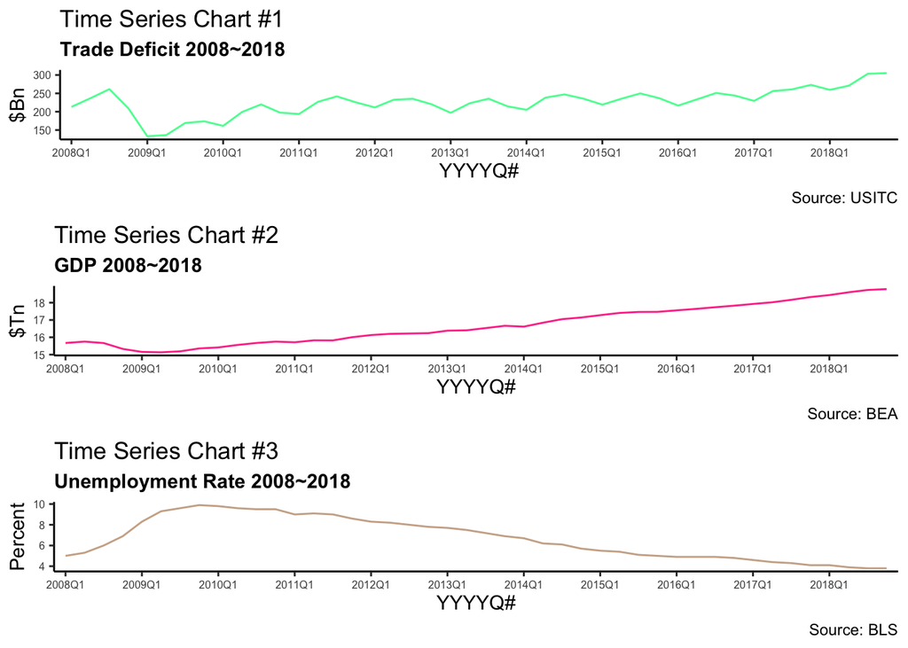

```r
chart1 <- ggplot(e) +
  geom_line(aes(x = Quarters, y = TradeDeficit_Size_Bn, group = 1), color = "seagreen1") +
  labs(
    title = "Time Series Chart #1",
    subtitle = "Trade Deficit 2008~2018",
    caption = "Source: USITC",
    y = "$Bn"
  ) +
  theme(
    panel.border = element_blank(),
    panel.grid.major = element_blank(),
    panel.grid.minor = element_blank(),
    panel.background = element_blank(),
    axis.text = element_text(size = 6),
    legend.position = "none",
    plot.subtitle = element_text(face = "bold"),
    axis.line = element_line(color = "black")
  ) +
  scale_x_discrete(
    name = "YYYYQ#",
    breaks = levels(e$Quarters)[c(TRUE, rep(FALSE, 3))]
  )

chart2 <- ggplot(e) +
  geom_line(aes(x = Quarters, y = GDP_Bn / 1e3, group = 1), color = "violetred1") +
  labs(
    title = "Time Series Chart #2",
    subtitle = "GDP 2008~2018",
    caption = "Source: BEA",
    y = "$Tn"
  ) +
  theme(
    panel.border = element_blank(),
    panel.grid.major = element_blank(),
    panel.grid.minor = element_blank(),
    panel.background = element_blank(),
    axis.text = element_text(size = 6),
    legend.position = "none",
    plot.subtitle = element_text(face = "bold"),
    axis.line = element_line(color = "black")
  ) +
  scale_x_discrete(
    name = "YYYYQ#",
    breaks = levels(e$Quarters)[c(TRUE, rep(FALSE, 3))]
  )

chart3 <- ggplot(e) +
  geom_line(aes(x = Quarters, y = UnemploymentRate_Q, group = 1), color = "peachpuff3") +
  labs(
    title = "Time Series Chart #3",
    subtitle = "Unemployment Rate 2008~2018",
    caption = "Source: BLS",
    y = "Percent"
  ) +
  theme(
    panel.border = element_blank(),
    panel.grid.major = element_blank(),
    panel.grid.minor = element_blank(),
    panel.background = element_blank(),
    axis.text = element_text(size = 6),
    legend.position = "none",
    plot.subtitle = element_text(face = "bold"),
    axis.line = element_line(color = "black")
  ) +
  scale_x_discrete(
    name = "YYYYQ#",
    breaks = levels(e$Quarters)[c(TRUE, rep(FALSE, 3))]
  )

grid.arrange(chart1, chart2, chart3)
```

Some more time series’ charts might help better understand the data…

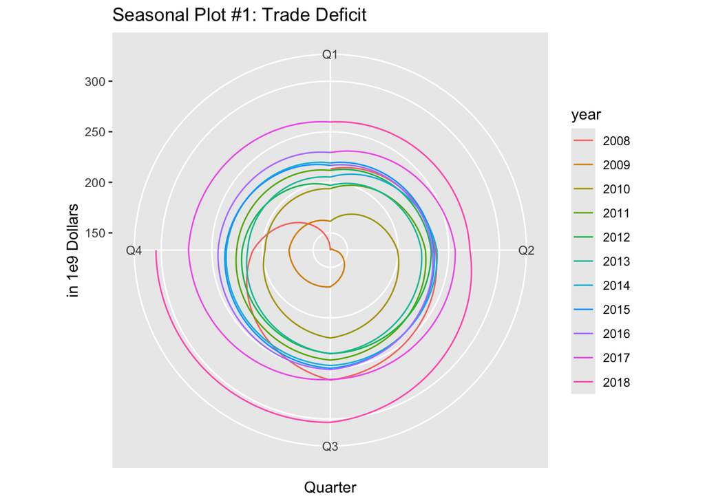

```r
ts_quarters <- ts(
  as.numeric(e$TradeDeficit_Size_Bn),
  start = c(2008, 1),
  end = c(2018, 4),
  frequency = 4
)

ggseasonplot(x = ts_quarters, polar = TRUE) +
  ylab("in 1e9 Dollars") +
  ggtitle("Seasonal Plot #1: Trade Deficit")
```

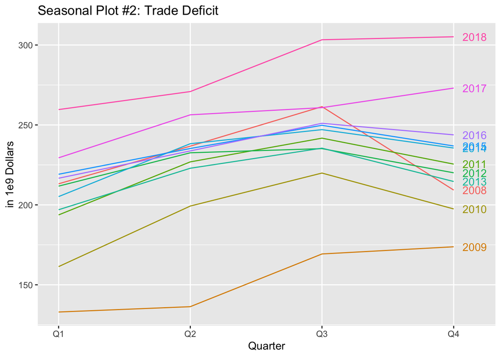

```r
ggseasonplot(x = ts_quarters, year.labels = TRUE, year.labels.left = FALSE) +
  ylab("in 1e9 Dollars") +
  ggtitle("Seasonal Plot #2: Trade Deficit")
```

That’s better in terms of understanding the seasonality of the trade deficit. So, we see the seasonal/annual patterns. I do however, for the purposes of this project, hone in on just one country (the U.S.), which would be my idnum in first differenced regression. It is therefore not necessary to do first differences. Instead of the First Differences then, let’s do something predictive, like Random Forests with time data.

### Random Forests & Predicting

Creating time lags: using GDP in $Q_{n-1}$ to predict GDP in $Q_n$:

```r
e <- e |>
  arrange(Quarters_Num) |>
  mutate(
    GDP_Bn_Lag1 = lag(GDP_Bn, 1L),
    TradeDeficit_Size_Bn_Lag1 = lag(TradeDeficit_Size_Bn, 1L),
    UnemploymentRate_Q_Lag1 = lag(UnemploymentRate_Q, 1L)
  )

training <- e |> filter(Quarters_Num <= 33)
testing <- e |> filter(Quarters_Num > 33)

rf <- randomForest(
  GDP_Bn ~ GDP_Bn_Lag1 + Quarters_Num + TradeDeficit_Size_Bn_Lag1 + UnemploymentRate_Q_Lag1,
  data = training,
  importance = TRUE,
  ntree = 1000,
  na.action = na.omit
)
```

What’s the most important predictor?

```r
imp <- as.data.frame(sort(importance(rf)[, 1], decreasing = TRUE), optional = TRUE)
names(imp) <- "% Inc. MSE"
imp
```

```
                          % Inc. MSE
GDP_Bn_Lag1                 26.77117
Quarters_Num                26.26610
UnemploymentRate_Q_Lag1     13.21146
TradeDeficit_Size_Bn_Lag1   10.41028
```

So, there are two conclusions to make here. One is that indeed, since all the trade deficit, the GDP, and the unemployment rate in some quarter $n$ are, apparently, to a large extent predicated on what the values for these variables were in quarter $n-1$, i.e. the previous one. This is to be expected in a time series for data such as the one I have. The second takeaway is that the Unemployment Rate is again acting up as a reflector of some of the other GDP elements, thus this variable’s predictiveness/importance may easily be overestimated by the model.

```r
which.min(rf$mse) # How many trees would suffice to get the smallest MSE?
```

```
[1] 58
```

Predict and evaluate on the testing set:

```r
y_hat <- predict(rf, newdata = testing)
defaultSummary(data.frame(obs = testing$GDP_Bn, pred = y_hat))
```

```
       RMSE    Rsquared         MAE
1053.318136    0.380464  967.367506
```

```r
h <- testing |>
  transmute(
    Quarters,
    Quarters_Num,
    GDP_Bn,
    GDP_Bn_RF = y_hat
  )
h
```

```
   Quarters Quarters_Num  GDP_Bn GDP_Bn_RF
1    2016Q2           34 17639.4  17202.15
2    2016Q3           35 17735.1  17267.55
3    2016Q4           36 17824.2  17318.00
4    2017Q1           37 17925.3  17319.37
5    2017Q2           38 18021.0  17255.27
6    2017Q3           39 18163.6  17196.72
7    2017Q4           40 18322.5  17196.72
8    2018Q1           41 18438.3  17196.72
9    2018Q2           42 18598.1  17196.72
10   2018Q3           43 18732.7  17196.72
11   2018Q4           44 18783.5  17196.72
```

RMSE is large in absolute billions, which is worrying for a levels forecast on a short univariate national series.

Ideally, we would like a smaller RMSE, but that would necessitate more data from more countries and possibly some more variables to throw in the model and to be able to try new models, maybe first differencing.

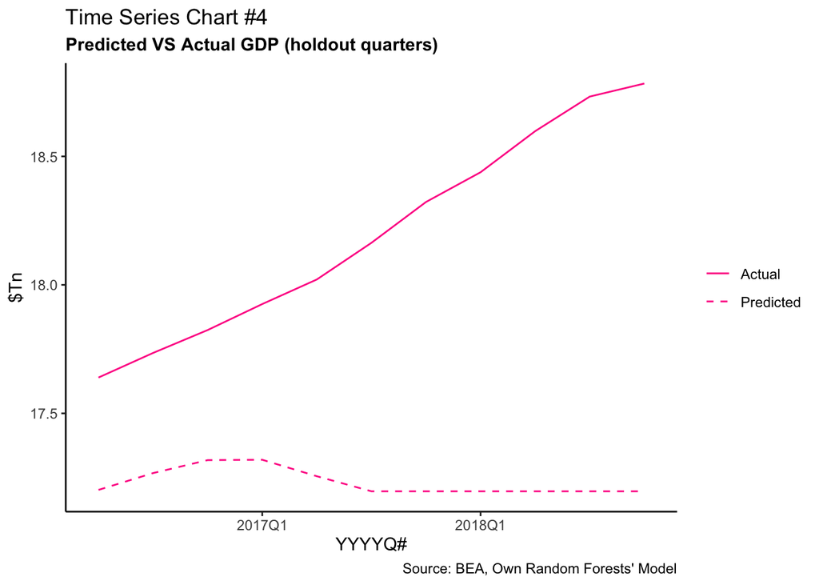

```r
chart4 <- ggplot(h) +
  geom_line(aes(x = Quarters, y = GDP_Bn / 1e3, group = 1, linetype = "Actual"), color = "deeppink1") +
  geom_line(aes(x = Quarters, y = GDP_Bn_RF / 1e3, group = 1, linetype = "Predicted"), color = "deeppink1") +
  labs(
    title = "Time Series Chart #4",
    subtitle = "Predicted VS Actual GDP (holdout quarters)",
    caption = "Source: BEA, Own Random Forests' Model",
    y = "$Tn",
    linetype = NULL
  ) +
  theme(
    panel.background = element_blank(),
    plot.subtitle = element_text(face = "bold"),
    axis.line = element_line(color = "black"),
    legend.key = element_blank()
  ) +
  scale_linetype_manual(values = c(Actual = "solid", Predicted = "dashed")) +
  scale_x_discrete(
    name = "YYYYQ#",
    breaks = levels(e$Quarters)[c(TRUE, rep(FALSE, 3))]
  )

chart4
```

Performs subpar on account of having too few observations (quarterly GDP figures for only a number of years)… This needs a Bayesian approach to fix. The takeaway is that the best model given some of the confines turned out to be, arguably, my Ordinal Logit.

# Findings/Conclusions

I have found that the most sensible model to use for this analysis was an Ordinal Logit Regression, which delivered statistically significant results.

According to this model, for each additional billion dollar increase in the Trade Deficit, the logit associated with going up one quintile in the GDP category increases (stat. signif.), as opposed to a lower category, net of other factors. That is, the odds of the GDP going up one quintile, as opposed to a lower quintile, net of all else, increase by $\mathrm{e}^{\hat\beta}-1$. This would indicate a positive *associational* relationship between the trade deficit and the output in these levels data. Further research is necessary to explore some other interactions, to iron out deficiencies in the panel time series predictivity of random forests given the nature of the present data, and to separate shared trends from structural effects (e.g. via differences or richer covariates). More countries would also have to be taken into account if generalizations were to be made. This, however, is a promising start.